# ColorLCAPlot

### Visualization of the photometry chains

This notebook has some simple visualizations of the flux+LCA chains derived for each TNO in this data release.

The key idea is that each chain has several realizations of the 5-dimensional $(f_g, f_r, f_i, f_z, A)$ parameter space, where each $f_b$ is the mean flux in band $b$ (normalized to 30 au from the observer and the Sun, and with zeropoint defined to be 30 mag) and $A$ the lightcurve amplitude. These can be projected into different parameters, for example: At band $b$, the absolute magnitude (at 1 au from the Sun and observer) is $$H_b = -2.5\log_{10}(f_b) + 30 - 5\log_{10} (30 \, \mathrm{au} \cdot 30 \, \mathrm{au}). $$ The color between band $b$ and band $b'$ is $$b - b' = -2.5 \log_{10}(f_b/f_{b'}). $$ The peak-to-peak (magnitude space) lightcurve amplitude is $$\Delta m = 2.5\log_{10}\left(\frac{1+A}{1-A}\right) $$

Let's start with a few package imports, and reproduce the figures in the paper

```python
import numpy as np
import astropy.table as tb
import matplotlib.pyplot as pl
```

Let's start with the figures for 2016 $\text{SD}_{106}$:

```python
data_sd = tb.Table.read('../fluxes/2016SD106.hdf5', 'data')
chain_sd  = tb.Table.read('../fluxes/2016SD106.hdf5', 'samples')
```

What is actually inside these tables?

For the flux measurements, we have, for each observation (and each object):

- `EXPNUM`: exposure number
- `BAND`: band
- `PHASE`: phase angle of the measurement (in radians)
- `PHASEPA`: position angle of the phase
- `RANGE`: topocentric distance (in AU)
- `SOLARD`: heliocentric distance (in AU)
- `TDB`: time of the observation (in years after J2000.0, TDB scale)
- `RA`: right ascension (degrees)
- `DEC`: declination (degrees)
- `FLUX_30AU`: flux scaled to 30 au
- `FLUXERR_30AU`: uncertainity in the flux, also scaled to 30 au
- `CLIPPED`: boolean variable that indicates if the observation was clipped from in the fitting procedure
- `MPC`: MPC identifier for the object

```python
data_sd.show_in_notebook()
```

*Table length=21*

| idx | EXPNUM | BAND | PHASE | RANGE | SOLARD | TDB | RA | DEC | FLUX_30AU | FLUXERR_30AU | CLIPPED | MPC |
| --- | --- | --- | --- | --- | --- | --- | --- | --- | --- | --- | --- | --- |
| 0 | 231513 | g | 0.001483844236620351 | 46.061056426647376 | 47.06622727612779 | 13.685583745059375 | 345.33951887216415 | -1.9646527203210586 | 2042.0648510809356 | 351.40770038994015 | False | 2016 SD106 |
| 1 | 232372 | g | 0.001631233640624255 | 46.05995899104533 | 47.0640717249118 | 13.69140357427126 | 345.30597725706065 | -1.9792074652159266 | 1054.3546804556684 | 382.50780551836004 | False | 2016 SD106 |
| 2 | 243465 | z | 0.012073572573280431 | 46.207010556530626 | 47.030906595364144 | 13.781098378319328 | 344.8357454289407 | -2.199259577263433 | 3298.054732647522 | 1124.9749892059663 | False | 2016 SD106 |
| 3 | 251739 | r | 0.018397706810954418 | 46.51294359304795 | 47.004631546217794 | 13.852361341694886 | 344.607264969896 | -2.3305393654679567 | 2074.616904801155 | 539.9011925365189 | False | 2016 SD106 |
| 4 | 563952 | z | 0.010752629717825648 | 45.153091322418994 | 46.03948252403555 | 16.61812476060759 | 350.0027385616483 | -0.2551063247665914 | 3090.765720832938 | 979.9068210427718 | False | 2016 SD106 |
| 5 | 577351 | r | 0.005178562649285117 | 45.02650975351513 | 46.00099531485876 | 16.73546939705775 | 349.34166066687516 | -0.5397779988989331 | 2676.5872869803793 | 294.6693448533363 | False | 2016 SD106 |
| 6 | 577352 | i | 0.005179057197602234 | 45.02651423558196 | 46.000994078672754 | 16.735473176304836 | 349.34163907062253 | -0.5397878872990363 | 4196.976856963835 | 457.5401284119624 | False | 2016 SD106 |
| 7 | 577353 | g | 0.0051795467858349814 | 45.02651867588168 | 46.00099285490837 | 16.73547691757742 | 349.3416176910577 | -0.5397976762884246 | 1860.6490468839086 | 230.00167830408247 | False | 2016 SD106 |
| 8 | 578989 | z | 0.0065879184879456 | 45.04191165762274 | 45.99742103566928 | 16.746399375784687 | 349.28114817858767 | -0.5682472502098207 | 3516.785021158775 | 690.6828744173396 | False | 2016 SD106 |
| 9 | 580853 | i | 0.008327076177724508 | 45.06758694892154 | 45.992952417068224 | 16.760071956728282 | 349.20806678804155 | -0.6033120737884182 | 4207.3319327846475 | 499.4657038522653 | False | 2016 SD106 |
| 10 | 580854 | r | 0.00832755604972304 | 45.06759496395282 | 45.99295118624674 | 16.760075723847137 | 349.20804671178905 | -0.6033216226783885 | 2528.4294289942786 | 324.1850734284211 | False | 2016 SD106 |
| 11 | 580855 | g | 0.008328037222549135 | 45.06760300401686 | 45.99294995208895 | 16.760079501178033 | 349.20802658114576 | -0.6033311973514054 | 2278.915045614712 | 268.62754170297114 | False | 2016 SD106 |
| 12 | 589685 | z | 0.017326709094275913 | 45.367841319721876 | 45.965353556025526 | 16.844707244949884 | 348.86091467358926 | -0.7879055460612574 | 4226.305157698211 | 895.0735726641316 | False | 2016 SD106 |
| 13 | 682009 | z | 0.004919485240297506 | 44.703363058959305 | 45.68075195273019 | 17.73757052054634 | 350.7998829803148 | -0.011814509827415488 | 4343.710356893673 | 719.7380501389758 | False | 2016 SD106 |
| 14 | 693877 | g | 0.017715248885448988 | 45.06528034828936 | 45.64504721059372 | 17.852333884140904 | 350.2960168816554 | -0.2732026000718123 | 1639.7419347135087 | 262.02605439573347 | False | 2016 SD106 |
| 15 | 693878 | r | 0.0177155514433127 | 45.06529861209109 | 45.645046051847594 | 17.852337619253117 | 350.2960068450573 | -0.2732087585385312 | 2764.3240471000295 | 343.8271957014758 | False | 2016 SD106 |
| 16 | 693879 | i | 0.01771585607267105 | 45.06531700518979 | 45.645044885091714 | 17.852341380184832 | 350.2959967402246 | -0.2732149593557416 | 3545.2399578360223 | 518.137013727976 | False | 2016 SD106 |
| 17 | 771956 | i | 0.0024323940568076892 | 44.38860313328957 | 45.38949652005288 | 18.693372582890536 | 352.551092701619 | 0.6470991960018508 | 3058.8443866147877 | 474.86040924976805 | False | 2016 SD106 |
| 18 | 774744 | r | 0.0014034584815506778 | 44.38137826228912 | 45.38459524625883 | 18.709856894264362 | 352.4537752408618 | 0.6037867904048008 | 3051.48312875345 | 261.7536959189203 | False | 2016 SD106 |
| 19 | 774745 | g | 0.0014035725278005674 | 44.38137800800806 | 45.38459413165833 | 18.709860644545472 | 352.4537527653073 | 0.603776833137059 | 1800.6167155114535 | 214.47507288164272 | False | 2016 SD106 |
| 20 | 775451 | z | 0.0017166165703461074 | 44.38132866090931 | 45.38302952764085 | 18.715125749349284 | 352.42274623429574 | 0.5897694471909484 | 1714.7408357069257 | 861.8556732338955 | False | 2016 SD106 |

And for the chains:

- `flux_grizY`: flux in the $grizY$ bands. This processing did not use the $Y$ band data, so these are all 0.
- `lca`: the lightcurve amplitude
- `logP`: log of the probability of this value (only needed for bookkeeping purposes)

```python
chain_sd.show_in_notebook()
```

*Table length=3125*

| idx | flux_g | flux_r | flux_i | flux_z | flux_Y | lca | logP |
| --- | --- | --- | --- | --- | --- | --- | --- |
| 0 | 1770.2530548360353 | 2970.635748601412 | 3482.290702509169 | 3207.4096923038087 | 0.0 | 0.07777111698569064 | 161.55417120072835 |
| 1 | 1732.5900370122183 | 2816.9110552104926 | 3964.8026692454446 | 3210.2658099313803 | 0.0 | 0.05706284636564685 | 159.82035556424543 |
| 2 | 1871.262375994116 | 2836.951985923355 | 3692.9349691003567 | 2528.9103290283365 | 0.0 | 0.09338163593123193 | 163.08433028133115 |
| 3 | 1843.7633409240432 | 2904.07457208664 | 3478.3422511157473 | 3072.050142825913 | 0.0 | 0.053539958330699466 | 160.76044672135203 |
| 4 | 1957.1947531712487 | 2609.0700406711467 | 3516.669604222652 | 3281.8209456126947 | 0.0 | 0.033572444822010675 | 160.17294314743512 |
| 5 | 2028.679457551312 | 2635.0297448928027 | 4007.103658472922 | 3215.432823974132 | 0.0 | 0.061516997902265516 | 161.5398497929995 |
| 6 | 2105.967618190317 | 2828.7129064277315 | 3668.229458107905 | 2836.5116141362205 | 0.0 | 0.17635042689695943 | 165.60032860916021 |
| 7 | 1610.8242588323708 | 2777.197901898119 | 3606.0637624596948 | 3169.358767954188 | 0.0 | 0.34917927066072735 | 165.33051361390417 |
| 8 | 1855.4319857566004 | 2711.400109593856 | 3542.972175101093 | 3454.7290070253807 | 0.0 | 0.27694666781576965 | 163.60531986210464 |
| 9 | 1695.2175648251894 | 2638.7806774973988 | 3913.6595472595004 | 4454.448577507456 | 0.0 | 0.17497112243275878 | 164.06280167331096 |
| 10 | 1632.446107718621 | 2680.368638577039 | 4034.0312616775723 | 3745.9542093649034 | 0.0 | 0.05378433826787973 | 161.0112621472482 |
| 11 | 1651.5834524531253 | 2598.973105558788 | 3821.6441980006753 | 3682.2341972140657 | 0.0 | 0.024554259426849724 | 160.32478903098516 |
| 12 | 1761.9549573626546 | 2476.8984389096054 | 3436.1316605515353 | 3209.5316957325695 | 0.0 | 0.059118474253914026 | 160.36084091460899 |
| 13 | 1652.8747877753624 | 2362.87869833969 | 3441.770126716369 | 3299.883702714361 | 0.0 | 0.12416882696426501 | 160.07458877516478 |
| 14 | 1636.956945666396 | 2324.76956428046 | 3637.859172587643 | 3289.1214150607016 | 0.0 | 0.1359030860903331 | 160.16833766993736 |
| 15 | 1885.1389788611705 | 2554.28291598316 | 3605.746347361206 | 3529.5115880506537 | 0.0 | 0.07841493527058119 | 159.52270422200976 |
| 16 | 1787.8983037996777 | 2715.4368079741325 | 3812.2690088995746 | 3308.1664474146755 | 0.0 | 0.007970235340138687 | 158.66616044150004 |
| 17 | 1802.742586582566 | 2709.7161164104928 | 3672.9080499693587 | 3755.052302213986 | 0.0 | 0.0476547599789205 | 159.05051912752126 |
| 18 | 1879.6901505327621 | 2569.890993051032 | 3555.2107263409257 | 3372.028039453632 | 0.0 | 0.06572033385971474 | 159.4369099708397 |
| 19 | 1743.9915594085492 | 2563.6125289557453 | 3880.0801025121414 | 3680.6175597439187 | 0.0 | 0.0859955684606652 | 159.43835063009095 |
| 20 | 1752.9209325774511 | 2592.666836861739 | 3595.061662540964 | 3296.553102597226 | 0.0 | 0.1221722991211167 | 158.9128701701689 |
| 21 | 1556.356907584731 | 2596.234595789086 | 3964.966124424002 | 3259.3796931432025 | 0.0 | 0.25889380369413767 | 162.65431728585173 |
| 22 | 1403.6628850494405 | 2419.8712852046497 | 3644.2793936853022 | 3696.2074866763687 | 0.0 | 0.1283760996778524 | 163.86368575553783 |
| 23 | 1782.5020497119524 | 2740.1596304410195 | 4163.693264416189 | 4033.444212049359 | 0.0 | 0.06003090387455398 | 161.69906820769643 |
| 24 | 1670.9698870646712 | 2539.1827652285083 | 3846.058217210998 | 3825.5707186541927 | 0.0 | 0.0019246174730668322 | 161.0762880470269 |
| 25 | 1652.0668060347323 | 2775.1665797185547 | 4038.3569383488743 | 3113.198541980297 | 0.0 | 0.040295025842692275 | 160.92284651885538 |
| 26 | 1872.0476738000864 | 2814.7011606387396 | 3223.3153948525855 | 3653.054275266029 | 0.0 | 0.06201205545550473 | 161.6003419621191 |
| 27 | 1810.7112362779883 | 2882.5522493760604 | 3844.4993991342644 | 3709.535799354169 | 0.0 | 0.06590212703370057 | 159.98608734415257 |
| 28 | 1721.4225290979473 | 2815.619996275082 | 3574.0052484847442 | 4220.606324520712 | 0.0 | 0.08305025709468025 | 162.28949128448107 |
| 29 | 1824.8168860868236 | 2819.9730277937483 | 3621.882274075574 | 3617.720986744371 | 0.0 | 0.15073835547001332 | 161.10915932476493 |

[output cut: 3095 more lines]

Now onto the visualization - we will compare the colors of this object to those measured by [Chen et al (2022)](https://ui.adsabs.harvard.edu/abs/2022ApJ...937L..22C/abstract)

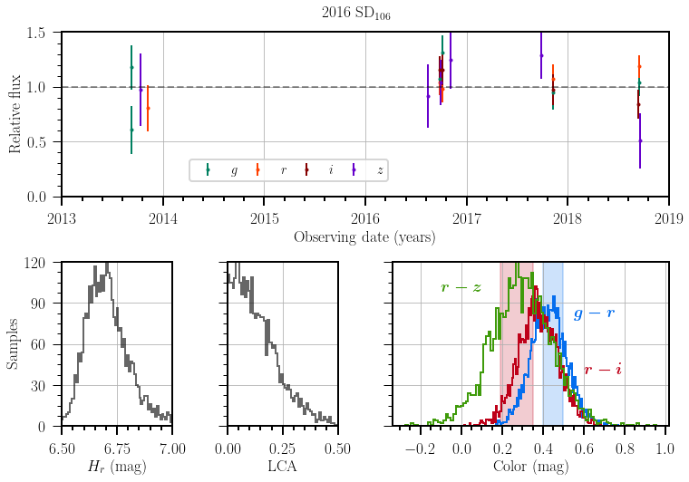

```python
#subplot_mosaic allows some really nice plots
fig, ax = pl.subplot_mosaic(
    '''
    AAAA
    BCDD
    ''')

### flux measurements
for i in ['g', 'r', 'i', 'z']:
    mean = np.mean(chain_sd[f'flux_{i}'])
    a = data_sd[data_sd['BAND'] == i]
    ax['A'].errorbar(2000+a['TDB'], a['FLUX_30AU']/mean, yerr=a['FLUXERR_30AU']/mean, fmt='.', color=BAND_COLORS[i],
                     label=r'${' + i + '}$')

ax['A'].set_xlim(2013,2019)
ax['A'].set_xlabel('Observing date (years)')
ax['A'].set_ylabel('Relative flux')
ax['A'].legend(ncol=4, loc=3,columnspacing=0.5,bbox_to_anchor=(0.2, 0.05))
ax['A'].axhline(1, linestyle='--', alpha=0.4)
ax['A'].set_ylim(0.,1.5)
ax['A'].grid()

### absolute magnitude
Hr = -2.5 * np.log10(chain_sd['flux_r']) - 10 * np.log10(30) + 30
ax['B'].hist(Hr, bins=100, histtype='step', density=False, color='k', alpha=0.6)
ax['B'].set_xlabel(r'$H_r$ (mag)')
ax['B'].set_ylabel('Samples')
ax['B'].set_ylim(0,120)
ax['B'].set_yticks([0,30,60,90,120])#,['','','','','']
ax['B'].grid()

### lightcurve amplitude - flux space
ax['C'].hist(chain_sd['lca'], bins=100, histtype='step', density = False, color='k', alpha=0.6)
ax['C'].set_xlabel(r'LCA')
ax['C'].set_yticks([0,30,60,90,120],['','','','',''])
ax['C'].set_ylim(0,120)
ax['C'].grid()
ax['C'].set_xlim(0,0.5)
ax['C'].set_xticks([0,  0.25, 0.5, ])#, [0,25,50])

### colors

ax['D'].hist(-2.5 * np.log10(chain_sd['flux_g']/chain_sd['flux_r']), histtype='step', bins=100, density=False, label=r'$g-r$')
ax['D'].hist(-2.5 * np.log10(chain_sd['flux_r']/chain_sd['flux_i']), histtype='step', bins=100, density=False, label=r'$r-i$')
ax['D'].hist(-2.5 * np.log10(chain_sd['flux_r']/chain_sd['flux_z']), histtype='step', bins=100, density=False, label=r'$r-z$')

# these correspond to measurements from Chen et al (2022)
ax['D'].axvspan(0.4, 0.5, alpha=0.2, color='xkcd:cerulean blue')
ax['D'].axvspan(0.19, 0.35, alpha=0.2, color='xkcd:scarlet')
ax['D'].set_xlabel('Color (mag)')
ax['D'].set_ylim(0,120)
ax['D'].set_yticks([0,30,60,90,120],['','','','',''])
ax['D'].grid()
ax['D'].text(0.55, 80, r'$\boldsymbol{g-r}$', fontsize=18, color='xkcd:cerulean blue')
ax['D'].text(0.6, 40, r'$\boldsymbol{r-i}$', fontsize=18, color='xkcd:scarlet')
ax['D'].text(-0.1, 100, r'$\boldsymbol{r-z}$', fontsize=18, color='xkcd:grass green')
ax['B'].set_xticks([6.5,6.75, 7])
ax['B'].set_xlim(6.5,7)
ax['D'].set_xticks([-0.2, 0, 0.2,0.4, 0.6, 0.8, 1.0,])


fig.subplots_adjust(hspace=0.4, wspace=0.5)
fig.set_size_inches(12,8)
pl.suptitle(r'2016 SD$_{106}$',y=0.93)
pl.show()
```

Now, for (612620) 2003 $\text{SQ}_{317}$. We'll be comparing with the $\Delta m = 0.85$ measured by [Lacerda et al (2014)](https://ui.adsabs.harvard.edu/abs/2014MNRAS.437.3824L/abstract).

Since $$\Delta m = 2.5 \log_{10} \left(\frac{1+A}{1-A}\right) \implies A = \frac{10^{0.4 \Delta m} - 1}{10^{0.4 \Delta m} + 1},$$

```python
Delta_m_Lacerda = 0.85
A_Lacerda = (10**(0.4 * Delta_m_Lacerda) - 1)/(10**(0.4 * Delta_m_Lacerda) + 1)

print(f'A = {A_Lacerda:.4f}')
```

```
A = 0.3726
```

Load the data and plot

```python
data_sq = tb.Table.read('../fluxes/2003SQ317.hdf5', 'data')
chain_sq = tb.Table.read('../fluxes/2003SQ317.hdf5', 'samples')
```

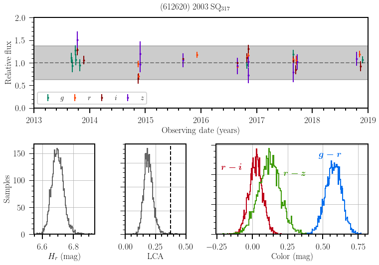

```python
fig, ax = pl.subplot_mosaic(
    '''
    AAAA
    BCDD
    ''')

### flux measurements

for i in ['g', 'r', 'i', 'z']:
    mean = np.mean(chain_sq[f'flux_{i}'])
    a = data_sq[data_sq['BAND'] == i]
    ax['A'].errorbar(2000+a['TDB'], a['FLUX_30AU']/mean, yerr=a['FLUXERR_30AU']/mean, fmt='.', color=BAND_COLORS[i],
                     label=r'${' + i + '}$')

ax['A'].set_xlim(2013,2019)
ax['A'].set_ylim(0,2)
ax['A'].set_xlabel('Observing date (years)',)
ax['A'].set_ylabel('Relative flux', )
ax['A'].legend(ncol=5, loc=3,columnspacing=0.5)
ax['A'].axhline(1, linestyle='--', alpha=0.4)

#Bands from Lacerda measurement
ax['A'].fill_between([2013, 2019], 1. + A_Lacerda, 1-A_Lacerda, alpha=0.2, color='k')
ax['A'].set_yticks([0,0.5, 1,1.5,2])

### absolute magnitude
ax['B'].hist(-2.5 * np.log10(chain_sq['flux_r']) - (10 * np.log10(30)) + 30, bins=100, histtype='step', density=False, color='k', alpha=0.6)
ax['B'].set_xlabel(r'$H_r$ (mag)', )

ax['B'].set_ylabel('Samples', )
ax['B'].grid()
ax['B'].set_yticks([0, 50, 100, 150])
ax['B'].set_yticks([0, 50, 100, 150])

### lca
ax['C'].hist(chain_sq['lca'], bins=100, histtype='step', density = False, color='k', alpha=0.6)
ax['C'].set_xlabel(r'LCA', )
ax['C'].grid()
ax['C'].set_xlim(0, 0.5)
ax['C'].set_xticks([0,0.25, 0.5])
ax['C'].set_yticks([0, 50, 100, 150], ['', '', '', ''])

# Lacerda measurement
ax['C'].axvline(A_Lacerda, linestyle='--')

### colors
ax['D'].hist(-2.5 * np.log10(chain_sq['flux_g']/chain_sq['flux_r']), histtype='step', bins=100, density=False, label=r'$g-r$')
ax['D'].hist(-2.5 * np.log10(chain_sq['flux_r']/chain_sq['flux_i']), histtype='step', bins=100, density=False, label=r'$g-i$')
ax['D'].hist(-2.5 * np.log10(chain_sq['flux_r']/chain_sq['flux_z']), histtype='step', bins=100, density=False, label=r'$g-z$')

ax['D'].set_xlabel('Color (mag)', )
ax['D'].grid()
ax['D'].text(0.47, 130, r'$\boldsymbol{g-r}$', fontsize=18, color='xkcd:cerulean blue')
ax['D'].text(-0.22, 110, r'$\boldsymbol{r-i}$', fontsize=18, color='xkcd:scarlet')
ax['D'].text(0.22, 100, r'$\boldsymbol{r-z}$', fontsize=18, color='xkcd:grass green')
ax['D'].set_yticks([0, 50, 100, 150], ['', '', '', ''])



fig.subplots_adjust(hspace=0.4, wspace=0.5)
fig.set_size_inches(12,8)
pl.suptitle(r'(612620) 2003 SQ$_{317}$',y=0.93)

pl.show()
```

In principle, we could produce 814 of these. Let's... not do that in this notebook.